# Load the Dataset

Loading the insurance dataset

```python
import pandas as pd

# Load the dataset
df = pd.read_csv('C:/Users/sadiy/insurance/insurance.csv')

# Preview the first few rows of the dataset
print(df.head())
```

```
   age     sex     bmi  children smoker     region      charges
0   19  female  27.900         0    yes  southwest  16884.92400
1   18    male  33.770         1     no  southeast   1725.55230
2   28    male  33.000         3     no  southeast   4449.46200
3   33    male  22.705         0     no  northwest  21984.47061
4   32    male  28.880         0     no  northwest   3866.85520
```

# Data Structure

Checking the data structure.

```python
# Get the number of rows and columns
print(f"Rows, Columns: {df.shape}")

# Get data types of each column
print(df.dtypes)
```

```
Rows, Columns: (1338, 7)
age           int64
sex          object
bmi         float64
children      int64
smoker       object
region       object
charges     float64
dtype: object
```

# Summary Statistics

Summary statistics for the numerical column such as age, BMI, and charges.

```python
# Generate descriptive statistics for numerical columns
print(df.describe())
```

```
               age          bmi     children       charges
count  1338.000000  1338.000000  1338.000000   1338.000000
mean     39.207025    30.663397     1.094918  13270.422265
std      14.049960     6.098187     1.205493  12110.011237
min      18.000000    15.960000     0.000000   1121.873900
25%      27.000000    26.296250     0.000000   4740.287150
50%      39.000000    30.400000     1.000000   9382.033000
75%      51.000000    34.693750     2.000000  16639.912515
max      64.000000    53.130000     5.000000  63770.428010
```

# Data Cleaning

Checking for any missing values.

```python
# Check for missing values
print(df.isnull().sum())
```

```
age         0
sex         0
bmi         0
children    0
smoker      0
region      0
charges     0
dtype: int64
```

# Visualizing the data

Ploting the distribution of charges to see how the target variable is distributed.

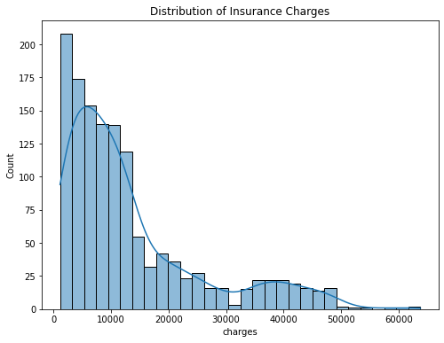

```python
import matplotlib.pyplot as plt
import seaborn as sns

# Plot the distribution of insurance charges
plt.figure(figsize=(8,6))
sns.histplot(df['charges'], kde=True)
plt.title('Distribution of Insurance Charges')
plt.show()
```

Pairplot for Numerical Variables: Using a pairplot to explore the relationships between different numerical features.

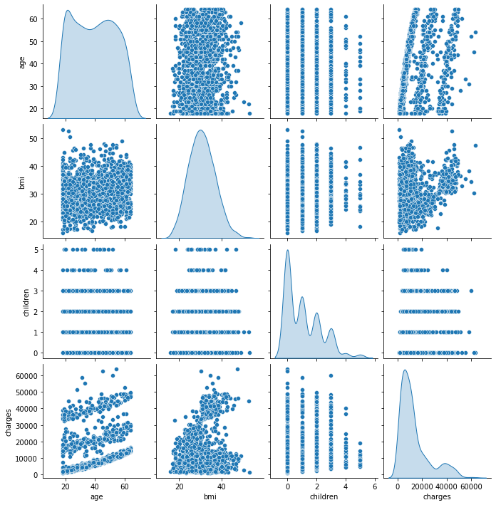

```python
# Pairplot to visualize relationships between numerical features
sns.pairplot(df[['age', 'bmi', 'children', 'charges']], diag_kind='kde')
plt.show()
```

# Data Preprocessing and Feature Engineering

Encode categorical features like sex, smoker, and region

```python
# Encode categorical variables
df['sex'] = df['sex'].map({'male': 0, 'female': 1})
df['smoker'] = df['smoker'].map({'yes': 1, 'no': 0})
df = pd.get_dummies(df, columns=['region'], drop_first=True)

# Check the changes
print(df.head())
```

```
   age  sex     bmi  children  smoker      charges  region_northwest  \
0   19    1  27.900         0       1  16884.92400                 0
1   18    0  33.770         1       0   1725.55230                 0
2   28    0  33.000         3       0   4449.46200                 0
3   33    0  22.705         0       0  21984.47061                 1
4   32    0  28.880         0       0   3866.85520                 1

   region_southeast  region_southwest
0                 0                 1
1                 1                 0
2                 1                 0
3                 0                 0
4                 0                 0
```

Splitting the Dataset: Splitting the dataset into features (X) and target (y), and then into training and testing sets.

```python
from sklearn.model_selection import train_test_split

# Define features and target
X = df.drop(columns=['charges'])
y = df['charges']

# Split the data into training and testing sets (80% train, 20% test)
X_train, X_test, y_train, y_test = train_test_split(X, y, test_size=0.2, random_state=42)

# Check the shape of training and testing data
print(f"Training Data Shape: {X_train.shape}")
print(f"Testing Data Shape: {X_test.shape}")
```

```
Training Data Shape: (1070, 8)
Testing Data Shape: (268, 8)
```

# Building a Basic Regression Model

Building a simple regression model using Linear Regression to predict insurance charges.

```python
from sklearn.linear_model import LinearRegression
from sklearn.metrics import mean_squared_error, r2_score

# Initialize the Linear Regression model
model = LinearRegression()

# Fit the model to the training data
model.fit(X_train, y_train)

# Predict on the test set
y_pred = model.predict(X_test)

# Evaluate the model
mse = mean_squared_error(y_test, y_pred)
r2 = r2_score(y_test, y_pred)

print(f"Mean Squared Error: {mse}")
print(f"R-Squared: {r2}")
```

```
Mean Squared Error: 33596915.851361446
R-Squared: 0.7835929767120724
```

# Model Improvement

Will try three advanced models: Decision Tree Regressor, Random Forest Regressor, and Gradient Boosting Regressor.

```python
from sklearn.tree import DecisionTreeRegressor
from sklearn.ensemble import RandomForestRegressor, GradientBoostingRegressor
from sklearn.metrics import mean_squared_error, r2_score

# Dictionary to store models and their results
models = {
    "Decision Tree": DecisionTreeRegressor(random_state=42),
    "Random Forest": RandomForestRegressor(random_state=42),
    "Gradient Boosting": GradientBoostingRegressor(random_state=42)
}

# Train and evaluate each model
for name, model in models.items():
    model.fit(X_train, y_train)
    y_pred = model.predict(X_test)
    mse = mean_squared_error(y_test, y_pred)
    r2 = r2_score(y_test, y_pred)
    print(f"{name} - Mean Squared Error: {mse:.2f}, R-Squared: {r2:.4f}")
```

```
Decision Tree - Mean Squared Error: 43389813.11, R-Squared: 0.7205
Random Forest - Mean Squared Error: 20709235.37, R-Squared: 0.8666
Gradient Boosting - Mean Squared Error: 18779431.72, R-Squared: 0.8790
```

Hyperparameter Tuning with Grid Search: performing hyperparameter tuning using GridSearchCV on Random Forest as an example.

```python
from sklearn.model_selection import GridSearchCV

# Define the parameter grid for Random Forest
param_grid = {
    'n_estimators': [50, 100, 200],
    'max_depth': [None, 10, 20, 30],
    'min_samples_split': [2, 5, 10]
}

# Initialize GridSearchCV
grid_search = GridSearchCV(
    estimator=RandomForestRegressor(random_state=42),
    param_grid=param_grid,
    cv=5,
    scoring='neg_mean_squared_error',
    n_jobs=-1
)

# Fit GridSearchCV
grid_search.fit(X_train, y_train)

# Get the best parameters and best score
print("Best Parameters:", grid_search.best_params_)
print("Best Score (MSE):", -grid_search.best_score_)

# Evaluate the best model on the test set
best_rf = grid_search.best_estimator_
y_pred = best_rf.predict(X_test)
print("Test Set Performance - MSE:", mean_squared_error(y_test, y_pred))
print("Test Set Performance - R²:", r2_score(y_test, y_pred))
```

```
Best Parameters: {'max_depth': 10, 'min_samples_split': 10, 'n_estimators': 200}
Best Score (MSE): 23126745.45505891
Test Set Performance - MSE: 19950430.145162065
Test Set Performance - R²: 0.8714937638880533
```

# Feature Engineering and Importance Analysis

Adding polynomial features can capture non-linear relationships. Creating polynomial features for selected columns.

```python
from sklearn.preprocessing import PolynomialFeatures

# Select the columns for polynomial transformation
poly = PolynomialFeatures(degree=2, include_bias=False)
X_train_poly = poly.fit_transform(X_train[['age', 'bmi']])
X_test_poly = poly.transform(X_test[['age', 'bmi']])

# Update the dataset with polynomial features
X_train_enhanced = pd.DataFrame(X_train_poly, columns=poly.get_feature_names_out(['age', 'bmi']))
X_test_enhanced = pd.DataFrame(X_test_poly, columns=poly.get_feature_names_out(['age', 'bmi']))
X_train_enhanced = pd.concat([X_train.reset_index(drop=True), X_train_enhanced], axis=1).drop(columns=['age', 'bmi'])
X_test_enhanced = pd.concat([X_test.reset_index(drop=True), X_test_enhanced], axis=1).drop(columns=['age', 'bmi'])

# Check the new shape of the enhanced datasets
print(X_train_enhanced.shape)
print(X_test_enhanced.shape)
```

```
(1070, 9)
(268, 9)
```

Feature Importance with Random Forest

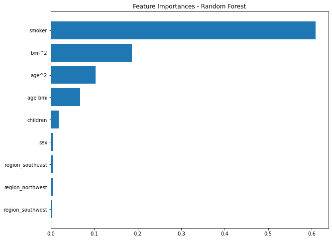

```python
# Fit the Random Forest model again on the enhanced data
rf_model = RandomForestRegressor(random_state=42)
rf_model.fit(X_train_enhanced, y_train)

# Plot feature importances
import matplotlib.pyplot as plt
import numpy as np

importances = rf_model.feature_importances_
indices = np.argsort(importances)[::-1]
features = X_train_enhanced.columns

plt.figure(figsize=(10, 8))
plt.title("Feature Importances - Random Forest")
plt.barh(range(len(indices)), importances[indices], align='center')
plt.yticks(range(len(indices)), [features[i] for i in indices])
plt.gca().invert_yaxis()
plt.show()
```

Feature Importance with SHAP: Using SHAP for interpretability with any model, here applied to Random Forest.

```python
!pip install shap
```

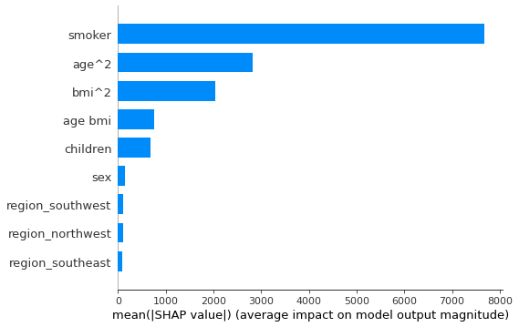

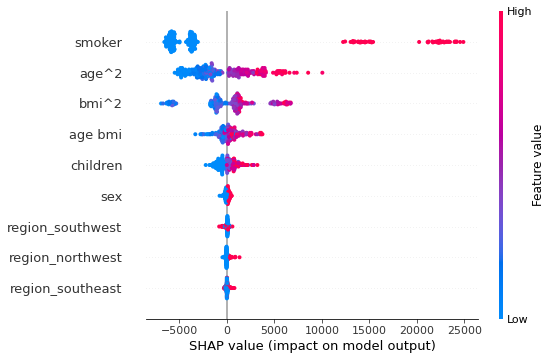

```python
import shap

# Initialize the SHAP explainer
explainer = shap.TreeExplainer(rf_model)
shap_values = explainer.shap_values(X_test_enhanced)

# Plot SHAP summary
shap.summary_plot(shap_values, X_test_enhanced, plot_type="bar")
shap.summary_plot(shap_values, X_test_enhanced)
```

# Model Evaluation and Interpretation

Evaluate Model Performance on the Test Set: Evaluating the best model selected from the previous steps on the test set for a final performance review.

```python
# Retrain the model on the enhanced dataset with polynomial features
best_model = grid_search.best_estimator_

# Fit the model on the enhanced training data
best_model.fit(X_train_enhanced, y_train)

# Predict on the enhanced test set
y_pred = best_model.predict(X_test_enhanced)

# Evaluate performance
mse = mean_squared_error(y_test, y_pred)
r2 = r2_score(y_test, y_pred)

print(f"Final Model - Mean Squared Error: {mse:.2f}")
print(f"Final Model - R-Squared: {r2:.4f}")
```

```
Final Model - Mean Squared Error: 19488547.73
Final Model - R-Squared: 0.8745
```

Residual Analysis: Residual analysis helps to check the randomness of errors, indicating good model fit.

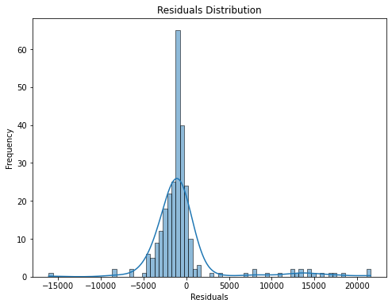

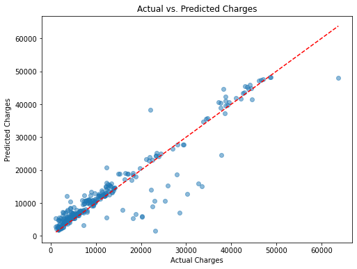

```python
# Calculate residuals
residuals = y_test - y_pred

# Plot residuals
plt.figure(figsize=(8,6))
sns.histplot(residuals, kde=True)
plt.title("Residuals Distribution")
plt.xlabel("Residuals")
plt.ylabel("Frequency")
plt.show()

# Scatter plot of predicted vs. actual
plt.figure(figsize=(8,6))
plt.scatter(y_test, y_pred, alpha=0.5)
plt.plot([y_test.min(), y_test.max()], [y_test.min(), y_test.max()], 'r--')
plt.xlabel("Actual Charges")
plt.ylabel("Predicted Charges")
plt.title("Actual vs. Predicted Charges")
plt.show()
```

# Addressing Outliers in Residuals

Will first calculate the residuals and then identify cases where residuals are significantly higher or lower than the typical range.

```python
# Calculate residuals
residuals = y_test - y_pred

# Add residuals to the test set for further analysis
X_test_enhanced['actual_charges'] = y_test
X_test_enhanced['predicted_charges'] = y_pred
X_test_enhanced['residuals'] = residuals
```

Identify Outliers in Residuals: Define a threshold to classify a residual as an outlier. Here, we use two standard deviations from the mean as a cutoff, but this can be adjusted.

```python
# Define threshold for outliers (e.g., two standard deviations)
import numpy as np

residual_mean = np.mean(residuals)
residual_std = np.std(residuals)
outlier_threshold = residual_mean + 2 * residual_std

# Identify outliers
outliers = X_test_enhanced[np.abs(X_test_enhanced['residuals']) > outlier_threshold]

# Display outliers
print("Number of outliers:", outliers.shape[0])
print(outliers[['actual_charges', 'predicted_charges', 'residuals']].head())
```

```
Number of outliers: 3
     actual_charges  predicted_charges     residuals
51       3579.82870        4655.160430  -8560.483908
115     30259.99556        4801.051218  17419.836966
128     32734.18630       15070.211418  16861.117324
```

Analyze Outliers: Examine outliers to see if there are patterns (e.g., most are smokers or have high BMI). This can give insights into why the model struggles with certain cases.

```python
print(X_test_enhanced.columns)
```

```
Index(['sex', 'children', 'smoker', 'region_northwest', 'region_southeast',
       'region_southwest', 'age^2', 'age bmi', 'bmi^2', 'actual_charges',
       'predicted_charges', 'residuals'],
      dtype='object')
```

```python
# Add 'smoker' and 'bmi' back to the enhanced DataFrame, if missing
X_test_enhanced['smoker'] = X_test['smoker'].values
X_test_enhanced['bmi'] = X_test['bmi'].values
```

Analyze Outliers: Examine outliers to see if there are patterns (e.g., most are smokers or have high BMI). This can give insights into why the model struggles with certain cases.

```python
# Now, analyze outliers by smoker status and high BMI
outliers = X_test_enhanced[np.abs(X_test_enhanced['residuals']) > outlier_threshold]
print(outliers.groupby(['smoker', 'bmi']).size())
```

```
smoker  bmi
0       29.37    1
        33.00    1
        35.20    1
dtype: int64
```